# COMP 162 Project Write-Up

# Introduction

Link to the dataset: https://www.kaggle.com/datasets/likithagedipudi/starbucks-customer-ordering-patterns

Description of dataset: This analysis explores a dataset of 100,000 Starbucks orders placed across store locations in the United States between 2024 and 2025. The dataset includes customer demographics (age group, gender, rewards membership), order details (cart size, number of customizations, drink category, order channel), store attributes (location type, region), and outcomes (total spend, fulfillment time, and customer satisfaction rated 1–5). No missing values were found, and no filtering or modifications were made to the dataset before analysis.

# Hypothesis generation and exploration

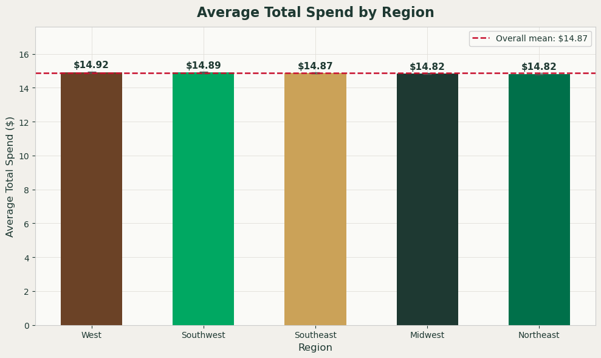

```python
#Q1: Are there regional differences in average total spend?
import pandas as pd
import matplotlib.pyplot as plt
import numpy as np
import warnings
warnings.filterwarnings('ignore')

df = pd.read_csv('starbucks.csv')

STARBUCKS_DARK  = '#1E3932'
STARBUCKS_CREAM = '#F2F0EB'
STARBUCKS_GREEN = '#00704A'

REGION_COLORS = {
    'Northeast': '#00704A',
    'Southeast': '#CBA258',
    'Midwest'  : '#1E3932',
    'Southwest': '#00A862',
    'West'     : '#6B4226',
}

CHANNEL_COLORS = {
    'Drive-Thru'        : '#00704A',
    'Mobile App'        : '#CBA258',
    'In-Store Cashier'  : '#1E3932',
    'Kiosk'             : '#00A862',
}

plt.rcParams.update({
    'font.family'     : 'DejaVu Sans',
    'figure.facecolor': STARBUCKS_CREAM,
    'axes.facecolor'  : '#FAFAF7',
    'axes.edgecolor'  : '#CCCCCC',
    'axes.grid'       : True,
    'grid.color'      : '#E0DED8',
    'grid.linewidth'  : 0.6,
    'text.color'      : STARBUCKS_DARK,
    'axes.labelcolor' : STARBUCKS_DARK,
    'xtick.color'     : STARBUCKS_DARK,
    'ytick.color'     : STARBUCKS_DARK,
})

# PLOT 1 — Average Total Spend by Region
region_order = df.groupby('region')['total_spend'].mean().sort_values(ascending=False).index.tolist()
region_means = df.groupby('region')['total_spend'].mean().reindex(region_order)
region_sems  = df.groupby('region')['total_spend'].sem().reindex(region_order)

fig1, ax1 = plt.subplots(figsize=(10, 6), facecolor=STARBUCKS_CREAM)

bars = ax1.bar(region_order,
               region_means.values,
               color=[REGION_COLORS[r] for r in region_order],
               edgecolor='none', width=0.55,
               yerr=region_sems.values, capsize=5,
               error_kw=dict(ecolor='#555555', elinewidth=1.5))

# Value labels on bars
for bar, val in zip(bars, region_means.values):
    ax1.text(bar.get_x() + bar.get_width() / 2, bar.get_height() + 0.15,
             f'${val:.2f}', ha='center', va='bottom',
             fontsize=11, fontweight='bold', color=STARBUCKS_DARK)

ax1.set_title('Average Total Spend by Region',
              fontsize=16, fontweight='bold', color=STARBUCKS_DARK, pad=12)
ax1.set_xlabel('Region', fontsize=12)
ax1.set_ylabel('Average Total Spend ($)', fontsize=12)
ax1.set_ylim(0, region_means.max() * 1.18)
ax1.yaxis.grid(True)
ax1.set_axisbelow(True)

# Overall mean reference line
overall_mean = df['total_spend'].mean()
ax1.axhline(overall_mean, color='#C8102E', linewidth=1.8, linestyle='--',
            label=f'Overall mean: ${overall_mean:.2f}')
ax1.legend(fontsize=10, framealpha=0.9)

plt.tight_layout()
plt.show()
```

Interpretation of plot: The bar chart shows that average total spend is nearly identical across all five regions, ranging narrowly from $14.82 to $14.92. The West has the highest average spend while the Midwest and Northeast are tied for the lowest. Overall, regional location appears to have very little impact on how much customers spend at Starbucks.

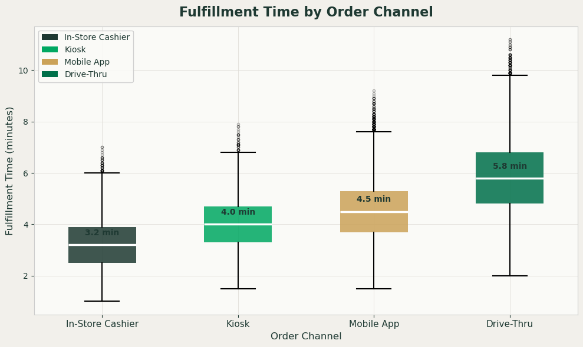

```python
#Q2: Does order channel affect fulfillment time?
# PLOT 2 — Fulfillment Time by Order Channel (box plot)

channel_order = df.groupby('order_channel')['fulfillment_time_min'].median().sort_values().index.tolist()

fig2, ax2 = plt.subplots(figsize=(10, 6), facecolor=STARBUCKS_CREAM)

data_by_channel = [df[df['order_channel'] == ch]['fulfillment_time_min'].values for ch in channel_order]

bp = ax2.boxplot(data_by_channel,
                 patch_artist=True,
                 widths=0.5,
                 medianprops=dict(color='white', linewidth=2.5),
                 whiskerprops=dict(linewidth=1.5),
                 capprops=dict(linewidth=1.5),
                 flierprops=dict(marker='o', markersize=3, alpha=0.3, linestyle='none'))

for patch, ch in zip(bp['boxes'], channel_order):
    patch.set_facecolor(CHANNEL_COLORS[ch])
    patch.set_alpha(0.85)
    patch.set_edgecolor('none')

# Median labels
for i, ch in enumerate(channel_order):
    med = df[df['order_channel'] == ch]['fulfillment_time_min'].median()
    ax2.text(i + 1, med + 0.3, f'{med:.1f} min',
             ha='center', va='bottom', fontsize=10,
             fontweight='bold', color=STARBUCKS_DARK)

ax2.set_xticks(range(1, len(channel_order) + 1))
ax2.set_xticklabels(channel_order, fontsize=11)
ax2.set_title('Fulfillment Time by Order Channel',
              fontsize=16, fontweight='bold', color=STARBUCKS_DARK, pad=12)
ax2.set_xlabel('Order Channel', fontsize=12)
ax2.set_ylabel('Fulfillment Time (minutes)', fontsize=12)
ax2.yaxis.grid(True)
ax2.set_axisbelow(True)

# Legend patches
from matplotlib.patches import Patch
legend_elements = [Patch(facecolor=CHANNEL_COLORS[ch], label=ch) for ch in channel_order]
ax2.legend(handles=legend_elements, fontsize=10, framealpha=0.9)

plt.tight_layout()
plt.show()
```

Interpretation of plot: The box plot shows a clear difference in fulfillment time across order channels. In-Store cashier orders are fulfilled the fastest with a median time of 3.2 minutes, followed by Kiosk at 4.0 minutes and Mobile App at 4.5 minutes. Drive-Thru is the slowest at 5.8 minutes and also shows the most outliers, suggesting occasional significant delays. Overall, order channel does appear to have a meaningful effect on fulfillment time.

# Machine Learning

```
=======================================================
MODEL 1: Linear Regression → Predicting total_spend
=======================================================
  MAE  : $0.94
  RMSE : $1.15
  R²   : 0.9574
```

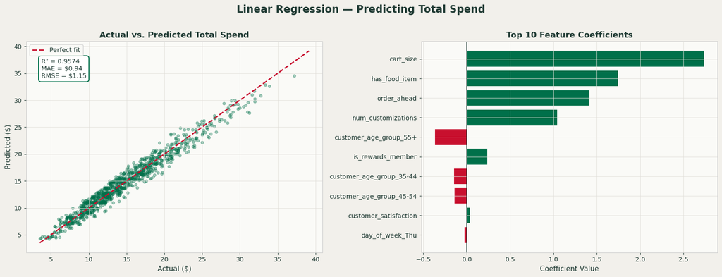

```python
#Linear Regression
#Independent variables: all available features in the dataset including cart size, number of customizations, rewards membership, food item, order ahead, total spend, fulfillment time, customer satisfaction, day of week, store location type, region, customer age group, customer gender, and drink category.
#Dependent variable: total_spend
import pandas as pd
import numpy as np
import matplotlib.pyplot as plt
import warnings
warnings.filterwarnings('ignore')

from sklearn.linear_model import LinearRegression, LogisticRegression
from sklearn.model_selection import train_test_split
from sklearn.preprocessing import LabelEncoder
from sklearn.metrics import (mean_absolute_error, r2_score, root_mean_squared_error,
                             classification_report, confusion_matrix, ConfusionMatrixDisplay)

df = pd.read_csv('starbucks.csv')

STARBUCKS_DARK  = '#1E3932'
STARBUCKS_CREAM = '#F2F0EB'
STARBUCKS_GREEN = '#00704A'

plt.rcParams.update({
    'font.family'     : 'DejaVu Sans',
    'figure.facecolor': STARBUCKS_CREAM,
    'axes.facecolor'  : '#FAFAF7',
    'axes.edgecolor'  : '#CCCCCC',
    'axes.grid'       : True,
    'grid.color'      : '#E0DED8',
    'grid.linewidth'  : 0.6,
    'text.color'      : STARBUCKS_DARK,
    'axes.labelcolor' : STARBUCKS_DARK,
    'xtick.color'     : STARBUCKS_DARK,
    'ytick.color'     : STARBUCKS_DARK,
})

# Encode categorical features
cat_cols = ['day_of_week', 'store_location_type', 'region',
            'customer_age_group', 'customer_gender', 'drink_category']

df_encoded = pd.get_dummies(df, columns=cat_cols, drop_first=True)
df_encoded['is_rewards_member'] = df_encoded['is_rewards_member'].astype(int)
df_encoded['has_food_item']     = df_encoded['has_food_item'].astype(int)
df_encoded['order_ahead']       = df_encoded['order_ahead'].astype(int)


# MODEL 1 — Linear Regression to predict total_spend

print("=" * 55)
print("MODEL 1: Linear Regression → Predicting total_spend")
print("=" * 55)

FEATURES_REG = ['cart_size', 'num_customizations', 'is_rewards_member',
                'has_food_item', 'order_ahead',
                'fulfillment_time_min', 'customer_satisfaction']

# Add any get_dummies columns that came from our cat_cols
extra_cols = [c for c in df_encoded.columns if any(
    c.startswith(p) for p in ['day_of_week_', 'store_location_type_',
                               'region_', 'customer_age_group_',
                               'customer_gender_', 'drink_category_'])]
FEATURES_REG += extra_cols

X_reg = df_encoded[FEATURES_REG]
y_reg = df_encoded['total_spend']

X_train_r, X_test_r, y_train_r, y_test_r = train_test_split(
    X_reg, y_reg, test_size=0.2, random_state=42)

lr = LinearRegression()
lr.fit(X_train_r, y_train_r)
y_pred_r = lr.predict(X_test_r)

mae  = mean_absolute_error(y_test_r, y_pred_r)
rmse = root_mean_squared_error(y_test_r, y_pred_r)
r2   = r2_score(y_test_r, y_pred_r)

print(f"  MAE  : ${mae:.2f}")
print(f"  RMSE : ${rmse:.2f}")
print(f"  R²   : {r2:.4f}")

# Top 10 coefficients
coef_df = pd.DataFrame({'feature': FEATURES_REG, 'coefficient': lr.coef_})
coef_df = coef_df.reindex(coef_df['coefficient'].abs().sort_values(ascending=False).index)
top10 = coef_df.head(10)

fig1, axes1 = plt.subplots(1, 2, figsize=(16, 6), facecolor=STARBUCKS_CREAM)

# Left: Actual vs Predicted
ax = axes1[0]
sample = np.random.RandomState(42).choice(len(y_test_r), 1000, replace=False)
ax.scatter(y_test_r.iloc[sample], y_pred_r[sample],
           alpha=0.35, s=18, color=STARBUCKS_GREEN, rasterized=True)
mn, mx = y_test_r.min(), y_test_r.max()
ax.plot([mn, mx], [mn, mx], color='#C8102E', linewidth=2, linestyle='--', label='Perfect fit')
ax.set_title('Actual vs. Predicted Total Spend', fontsize=13, fontweight='bold', color=STARBUCKS_DARK)
ax.set_xlabel('Actual ($)', fontsize=11)
ax.set_ylabel('Predicted ($)', fontsize=11)
ax.text(0.05, 0.92, f'R² = {r2:.4f}\nMAE = ${mae:.2f}\nRMSE = ${rmse:.2f}',
        transform=ax.transAxes, fontsize=10, va='top',
        bbox=dict(boxstyle='round,pad=0.4', facecolor='white',
                  edgecolor=STARBUCKS_GREEN, linewidth=1.5))
ax.legend(fontsize=10)

# Right: Top 10 coefficients
ax2 = axes1[1]
bar_colors = [STARBUCKS_GREEN if v > 0 else '#C8102E' for v in top10['coefficient']]
ax2.barh(top10['feature'][::-1], top10['coefficient'][::-1],
         color=bar_colors[::-1], edgecolor='none')
ax2.axvline(0, color=STARBUCKS_DARK, linewidth=1.2)
ax2.set_title('Top 10 Feature Coefficients', fontsize=13, fontweight='bold', color=STARBUCKS_DARK)
ax2.set_xlabel('Coefficient Value', fontsize=11)

fig1.suptitle('Linear Regression — Predicting Total Spend',
              fontsize=16, fontweight='bold', color=STARBUCKS_DARK, y=1.01)
plt.tight_layout()
plt.show()
```

The model achieved an R² of 0.96 and a mean absolute error of 0.94, meaning predictions are off by less than a dollar on average. Cart size, having a food item, and ordering ahead were the strongest predictors of total spend. Older age groups (55+, 35-44, 45-54) were associated with slightly lower spend. Given its strong performance, we would recommend this model for future predictions. There is no strong evidence of overfitting given the high R² and low MAE on the test set.

```
=======================================================
MODEL 2: Logistic Regression → Predicting order_channel
=======================================================
                  precision    recall  f1-score   support

      Drive-Thru       0.74      0.83      0.79      5579
In-Store Cashier       0.67      0.82      0.74      4451
           Kiosk       0.00      0.00      0.00      1484
      Mobile App       0.96      0.94      0.95      8486

        accuracy                           0.81     20000
       macro avg       0.59      0.65      0.62     20000
    weighted avg       0.76      0.81      0.79     20000
```

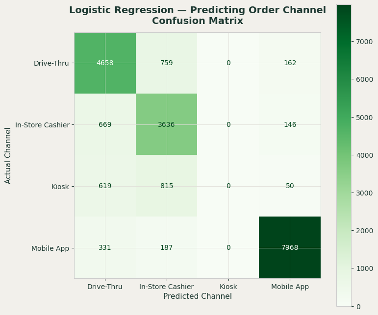

```python
# MODEL 2 — Logistic Regression to predict order_channel
#Independent variables: All available features in the dataset including cart size, number of customizations, rewards membership, food item, order ahead, total spend, fulfillment time, customer satisfaction, day of week, store location type, region, customer age group, customer gender, and drink category.
#Dependent variable: order_channel

print("=" * 55)
print("MODEL 2: Logistic Regression → Predicting order_channel")
print("=" * 55)

FEATURES_CLF = ['cart_size', 'num_customizations', 'is_rewards_member',
                'has_food_item', 'order_ahead', 'total_spend',
                'fulfillment_time_min', 'customer_satisfaction']
FEATURES_CLF += [c for c in df_encoded.columns if any(
    c.startswith(p) for p in ['day_of_week_', 'store_location_type_',
                               'region_', 'customer_age_group_',
                               'customer_gender_', 'drink_category_'])]

X_clf = df_encoded[FEATURES_CLF]
y_clf = df['order_channel']

X_train_c, X_test_c, y_train_c, y_test_c = train_test_split(
    X_clf, y_clf, test_size=0.2, random_state=42)

log = LogisticRegression(max_iter=1000, random_state=42)
log.fit(X_train_c, y_train_c)
y_pred_c = log.predict(X_test_c)

print(classification_report(y_test_c, y_pred_c))

# Confusion matrix
fig2, ax3 = plt.subplots(figsize=(8, 7), facecolor=STARBUCKS_CREAM)
cm = confusion_matrix(y_test_c, y_pred_c, labels=log.classes_)
disp = ConfusionMatrixDisplay(confusion_matrix=cm, display_labels=log.classes_)
disp.plot(ax=ax3, colorbar=True, cmap='Greens')
ax3.set_title('Logistic Regression — Predicting Order Channel\nConfusion Matrix',
              fontsize=14, fontweight='bold', color=STARBUCKS_DARK, pad=12)
ax3.set_xlabel('Predicted Channel', fontsize=11)
ax3.set_ylabel('Actual Channel', fontsize=11)

plt.tight_layout()
plt.show()
```

The model was evaluated using accuracy and a confusion matrix. It performed well for Mobile App orders (7,968 correct classifications) and reasonably well for Drive-Thru and In-Store Cashier, but failed to correctly classify any Kiosk orders. This suggests that Kiosk ordering behavior is not easily distinguishable from other channels based on the available features. We would not fully recommend this model for future predictions.

# Ethical Considerations

This project raises several ethical considerations. First, customers did not explicitly consent to having their ordering behavior used for predictive modeling, which raises concerns around privacy and respect for persons. Second, the use of demographic variables like age group and gender in our models could unintentionally reinforce existing disparities if the model performs better for some groups than others. As discussed in class, our models are only as good as our data, meaning any bias present in the data will carry over into the results.

# Conclusion

In this project, we found that average total spend is nearly identical across all five regions, ranging from $14.82 to $14.92, suggesting that regional location has little impact on spending. We also found that order channel does affect fulfillment time, with In-Store Cashier being the fastest at 3.2 minutes and Drive-Thru being the slowest at 5.8 minutes. Our linear regression model predicted total spend well with an R² of 0.96 and a mean absolute error of 0.94, with cart size, having a food item, and ordering ahead being the strongest predictors. Our logistic regression model performed well for Mobile App and Drive-Thru orders but failed to classify any Kiosk orders correctly, indicating that order channel is difficult to predict from behavioral features alone.